# FAST Engine: knowledge base

NSF Regional Innovation Engines, Cohort 2. Technology profile v1. Draft, in progress

**NSF FAST Engine in Oregon**, led by Oregon State University. NSF award 2532464, start August 2026. Search window for papers and patents: from August 2021 (five years before the award) onward.

## At a glance

| Measure | Value |
| --- | --- |
| People named by NSF or the Engine’s site | 14 |
| of them active researchers (>= 5 works since window start) | 1 |
| Team members who are inventors (2021-2025 grants, in the region) | 2 |
| Partners (site list + team members’ organisations) | 105 |
| Knowledge-producer partners (universities, labs, institutes) | 6 |
| Partner papers in the Engine’s topics | 63 |
| of them with an in-region partner | 63 |
| Regional patents in the technology profile (2021-2025 grants) | 3139 |
| Location quotient of the technology profile (patents) | 3.39 |
| Share of regional technology patents owned by partners | 72.3% |

## Economic base

| NAICS | Industry | Employment in region | Establishments | Share of US employment | Employment LQ |
| --- | --- | --- | --- | --- | --- |
| 3344 | Semiconductor and other electronic components | 23,268 | 86 | 8.3% | 6.85 |
| 3345 | Navigational, measuring, electromedical and control instruments | 5,487 | 89 | 1.3% | 1.09 |
| 5415 | Computer systems design and related services | 11,651 | 1,425 | 0.6% | 0.47 |

Industries related to the Engine’s technology (chosen from the NSF abstract, see `data/manual/engine_naics.csv`). County Business Patterns 2023; LQ = the industry’s share of regional employment relative to its share of US employment (1 = US average). Region: whole state(s).

## Technology profile

Version 1. The profile has 3 statements. Item 1 comes from the grant title, the rest from the technical part of the NSF abstract. Each statement is mapped to one OpenAlex topic and to CPC codes.

| # | Source | Statement | OpenAlex topic | Subfield | CPC |
| --- | --- | --- | --- | --- | --- |
| 1 | title | Advanced semiconductor technology | Semiconductor materials and devices | Electrical and Electronic Engineering | H01L; H10D |
| 2 | abstract | AI-enabled automatic process control for semiconductor manufacturing | Fault Detection and Control Systems | Control and Systems Engineering | H01L21; G05B19 |
| 3 | abstract | Design and manufacturing of advanced logic chips | VLSI and FPGA Design Techniques | Electrical and Electronic Engineering | G06F30; H01L21 |

## People

| Role | People |
| --- | --- |
| organizer | 12 |
| corporate_rd | 1 |
| researcher | 1 |

| Name | Role | On NSF award | Title | Organisation | Works since window (in Engine topics) | h-index | Patents 2021-25 (in Engine profile) | Site | OpenAlex |
| --- | --- | --- | --- | --- | --- | --- | --- | --- | --- |
| Pallavi Dhagat | researcher |  | FAST Co-Director of Research | Oregon State University | 21 (0) | 18 |  | [page](https://fast-engine.org/leadership/) | [profile](https://openalex.org/A5037916341) |
| Scott Mokler | corporate_rd |  | FAST Co-Director of Research | Intel, retired | 1 (1) | 4 | 3 (3) | [page](https://fast-engine.org/leadership/) | [profile](https://openalex.org/A5062941320) |
| Cara Turano | organizer |  | FAST Co-director of Translation, Entrepreneurship, and In… | Oregon Entrepreneur Network | - | - |  | [page](https://fast-engine.org/leadership/) |  |
| Christie Dudenhoefer | organizer |  | FAST Co-director of Partnership and Engagement | Oregon State University | - | - | 13 (0) | [page](https://fast-engine.org/leadership/) |  |
| Deb Mumm-Hill | organizer |  | FAST Co-Director of Workforce Development | STEM ED Consultant | - | - |  | [page](https://fast-engine.org/leadership/) |  |
| Julie Brandis | organizer |  | FAST Co-director of Partnership and Engagement | Oregon State University | - | - |  | [page](https://fast-engine.org/leadership/) |  |
| Kyle Ritchey-Noll | organizer |  | FAST Co-Director of Workforce Development | Oregon Business Council | - | - |  | [page](https://fast-engine.org/leadership/) |  |
| Larry Cheyne | organizer |  | FAST co-PI | Chemeketa College | - | - |  | [page](https://fast-engine.org/leadership/) |  |
| Rob Stone | organizer | PI | FAST Interim CEO | Oregon State University | - | - |  | [page](https://fast-engine.org/leadership/) |  |
| Shannon Carney | organizer | Co-PI | FAST co-PI | Business Oregon | - | - |  | [page](https://fast-engine.org/leadership/) |  |
| Shashi Jain | organizer |  | FAST Co-director of Translation, Entrepreneurship, and In… | Portland Seed Fund | - | - |  | [page](https://fast-engine.org/leadership/) |  |
| Skip Newberry | organizer | Co-PI | FAST Co-director of Translation, Entrepreneurship, and In… | Technology Association of Oregon | - | - |  | [page](https://fast-engine.org/leadership/) |  |
| Tim D Ray | organizer | Co-PI |  |  | - | - |  |  |  |
| Tina Guldberg | organizer | Co-PI | FAST Co-director of Partnership and Engagement | University of Oregon | - | - |  | [page](https://fast-engine.org/leadership/) |  |

Publication counts are shown only where the OpenAlex author matches both the name and the person’s current organisation. The OpenAlex link is given only for these reliable matches, and not for profiles flagged as possibly merging several namesakes. *Site* links to the page of the Engine’s website where the person is named. Click a number of works to see the list on the Publications page. *Patents*: US grants 2021-2025 with the person among the inventors (same last and first name, address in the Engine’s states); click the number for the list on the Patents page. In brackets: works in the Engine’s topics, patents with a CPC code in the Engine’s technology profile.

## Researchers at partner organisations

| # | Researcher | Partner | Works in the Engine’s topics | Citations | Years | Most cited of these works |
| --- | --- | --- | --- | --- | --- | --- |
| 1 | [John F. Conley](https://openalex.org/A5046500471) | Oregon State University | 11 | 45 | 2022-2026 | [Orientation-dependent β-Ga2O3 heterojunction diode with a…](https://openalex.org/W4414543038) |
| 2 | [Jessica Haglund-Peterson](https://openalex.org/A5032281000) | Oregon State University | 6 | 15 | 2022-2026 | [Plasma-enhanced atomic layer deposition of WO3-SiO2 films…](https://openalex.org/W4313417600) |
| 3 | [Cameron Souza](https://openalex.org/A5152017317) | Oregon State University | 6 | 0 | 2026 | [Forecast lead time is not a proper score for fault detect…](https://openalex.org/W7213504306) |
| 4 | [Malgorzata Chrzanowska-Jeske](https://openalex.org/A5040622659) | Portland State University | 5 | 11 | 2022-2026 | [RS3DPlace: Monolithic 3D IC placement using Reinforcement…](https://openalex.org/W4312746619) |
| 5 | [Shane M. W. Witsell](https://openalex.org/A5025201361) | Oregon State University | 4 | 20 | 2022-2025 | [Orientation-dependent β-Ga2O3 heterojunction diode with a…](https://openalex.org/W4414543038) |
| 6 | [Abdullah Mansoor](https://openalex.org/A5109594452) | Portland State University | 4 | 11 | 2022-2025 | [RS3DPlace: Monolithic 3D IC placement using Reinforcement…](https://openalex.org/W4312746619) |
| 7 | [Kathryn B. Newhart](https://openalex.org/A5036620672) | Oregon State University | 3 | 4 | 2025-2026 | [NDMA soft-sensors for potable reuse: A model development …](https://openalex.org/W4413439893) |
| 8 | [Xiaoyu Song](https://openalex.org/A5082437433) | Portland State University | 3 | 2 | 2023-2026 | [Bidirectional-Graph Attention Networks Parallel Encoder f…](https://openalex.org/W7130675810) |

The grant names mostly managers; the technology is often developed at the partner universities and labs. These are the authors with the most works in the Engine’s OpenAlex topics written at a knowledge-producer partner in the Engine’s states, since the window start (at least 3 works; top 15). The list depends on the technology profile version. OpenAlex sometimes merges namesakes into one author: check the profile before relying on a name.

## Partners

| Organisation class | Partners |
| --- | --- |
| intermediary | 37 |
| company | 33 |
| government | 11 |
| community_college | 8 |
| investor | 8 |
| university | 5 |
| philanthropy | 2 |
| national_lab | 1 |

Partner list on the site: *Complete (100 partners + 14 core partner logos)*.

| Partner | Class | State | OpenAlex works since window (all topics) |
| --- | --- | --- | --- |
| Pacific Northwest National Laboratory | national_lab | Washington | 1362797 |
| Oregon State University | university | Oregon | 30915 |
| University of Oregon | university | Oregon | 14993 |
| Portland State University | university | Oregon | 11194 |
| Willamette University | university | Oregon | 710 |
| Oregon Institute of Technology | university | Oregon | 471 |

## Science base: partner papers in the Engine’s topics

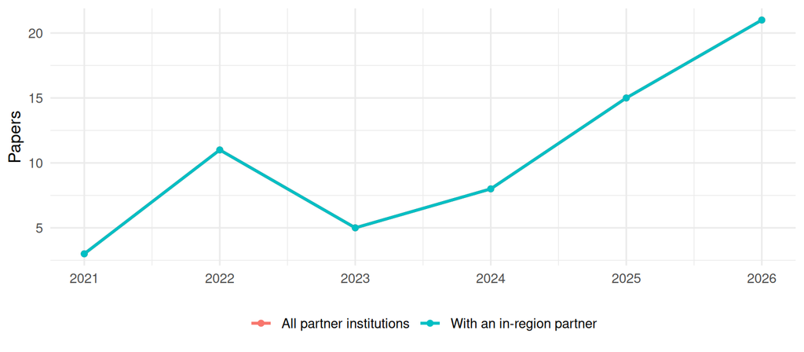

| Partner | Papers in topics |
| --- | --- |
| Oregon State University | 39 |
| Portland State University | 22 |
| Oregon Institute of Technology | 2 |

## Technology base: patents

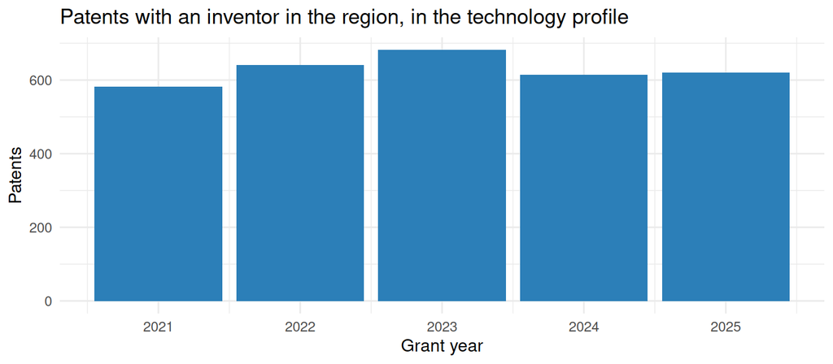

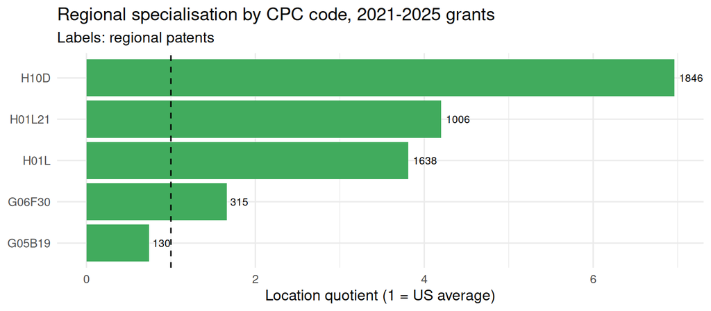

| Assignee | Regional patents in profile |
| --- | --- |
| Intel Corporation | 1708 |
| Kepler Computing Inc. | 219 |
| Lam Research Corporation | 163 |
| Monolithic 3D Inc. | 158 |
| Taiwan Semiconductor Manufacturing Company, Ltd. | 45 |
| Applied Materials, Inc. | 41 |
| State Farm Mutual Automobile Insurance Company | 38 |
| Synopsys, Inc. | 37 |
| SUNRISE MEMORY CORPORATION | 34 |
| SEMICONDUCTOR COMPONENTS INDUSTRIES, LLC | 31 |

Partner-owned patents invented in the region: 7408, of which 2270 (30.6%) fall in the Engine’s technology profile.

## Competition

With 3139 patents in the technology profile (2021-2025 grants), the Engine’s region would rank **4** among US states; its specialisation (LQ) is 3.394.

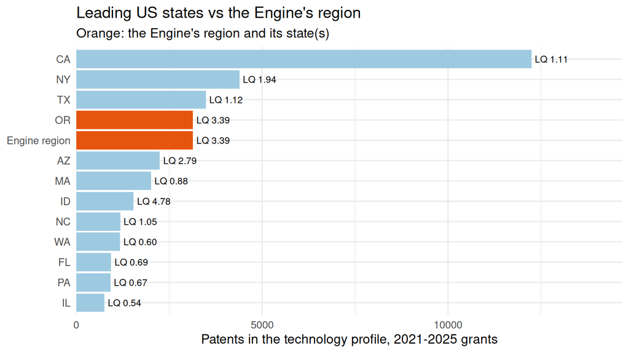

| Country | Share of US patents in profile | Share of world papers in topics |
| --- | --- | --- |
| US | 31.8% | 9.4% |
| JP | 19.2% | 3.0% |
| TW | 19.2% | 2.1% |
| KR | 11.4% | 4.6% |
| CN | 9.1% | 33.1% |
| DE | 4.1% | 3.9% |
| FR | 1.5% | 2.9% |
| IN | 1.4% | 7.8% |
| GB | 1.1% | 2.3% |
| CA | 1.0% | 1.7% |

Patents: inventor countries on US grants in the profile (a patent counts for every country of its inventors). Papers: author countries of OpenAlex works in the Engine’s topics since the window start.

## Data and limitations

- People: PIs and Co-PIs from the NSF Award API; leadership listed on the Engine’s website. Roles come from titles and organisations, revised with OpenAlex evidence.
- Partners: as listed on the Engine’s website, plus organisations of team members. Some Engines publish partner logos without names.
- Region: the Engine’s counties where the list is known (NEO-SMART: 18 Northeast Ohio counties; STELLAR: 11 counties from the NSF abstract), otherwise its states (state-level proxy).
- Technology profile: v1 (switch versions in the header). Partner papers and regional patents depend on it: v1 uses mostly CPC subclasses, the v3.1 core uses CPC main groups, which are narrower, so it counts fewer patents and the LQ of a small region rests on few patents.
- Papers: OpenAlex; partner papers are restricted to the Engine’s OpenAlex topics.
- Patents: USPTO grants 2021-2025; inventor locations from PatentsView; pre-grant publications are not included.